# Aula 10: Mapeamento Mimulus por IM e CIM

Ana Letycia Basso,Germano Costa Neto,Nathalia Salgado,Rafael Yassue

5 de julho de 2019

1. Considere o conjunto de dados de Mimulus, ja usado em aulas anteriores. Usando o mapa que voce construiu anteriormente com o OneMap, faca mapeamento por intervalo e por intervalo composto para localizar QTL’s para uma das caracteristicas presentes no conjunto de dados
1. Determine o limiar para rejeitar H0 e apresente os resultados de forma grafica e em tabelas de forma semelhante aos artigos publicados na area.

```r
library(qtl)
mimulus_qtl <- read.cross(format = "mm",file = "m_feb06.raw", mapfile="test_sum.txt")
```

```
##  --Read the following data:
##  Type of cross:          f2
##  Number of individuals:  287
##  Number of markers:      418
##  Number of phenotypes:   16
##  --Cross type: f2
```

1)Ajustando marcadores sobrepostos

```r
mimulus_jm= jittermap(mimulus_qtl)
summary(mimulus_jm)
```

```
##     F2 intercross
##
##     No. individuals:    287
##
##     No. phenotypes:     16
##     Percent phenotyped: 96.2 93.4 96.2 93 95.8 87.8 96.2 95.8 96.2 96.2
##                         90.2 96.2 95.8 96.2 95.8 96.2
##
##     No. chromosomes:    14
##         Autosomes:      1 2 3 4 5 6 7 8 9 10 11 12 13 14
##
##     Total markers:      379
##     No. markers:        19 20 24 36 19 18 43 32 35 37 24 26 21 25
##     Percent genotyped:  89.4
##     Genotypes (%):      AA:16.3  AB:25.3  BB:23.1  not BB:19.9  not AA:15.5
```

2)Probabilidades condionais

```r
mimulus.qtl.probs = calc.genoprob(mimulus_qtl, step=1, error.prob = 0.001)
```

3)Definindo o limiar a partir de permutacoes

```r
mimulus_qtl_perm= scanone(mimulus.qtl.probs, pheno.col = 4, method = "em", n.perm = 1000)
```

```r
summary(mimulus_qtl_perm, alpha= c(0.05, 0.01))
```

```
## LOD thresholds (1000 permutations)
##     lod
## 5% 3.76
## 1% 4.40
```

```r
threshold_im = summary(mimulus_qtl_perm, alpha = 0.05)
threshold_im
```

```
## LOD thresholds (1000 permutations)
##     lod
## 5% 3.76
```

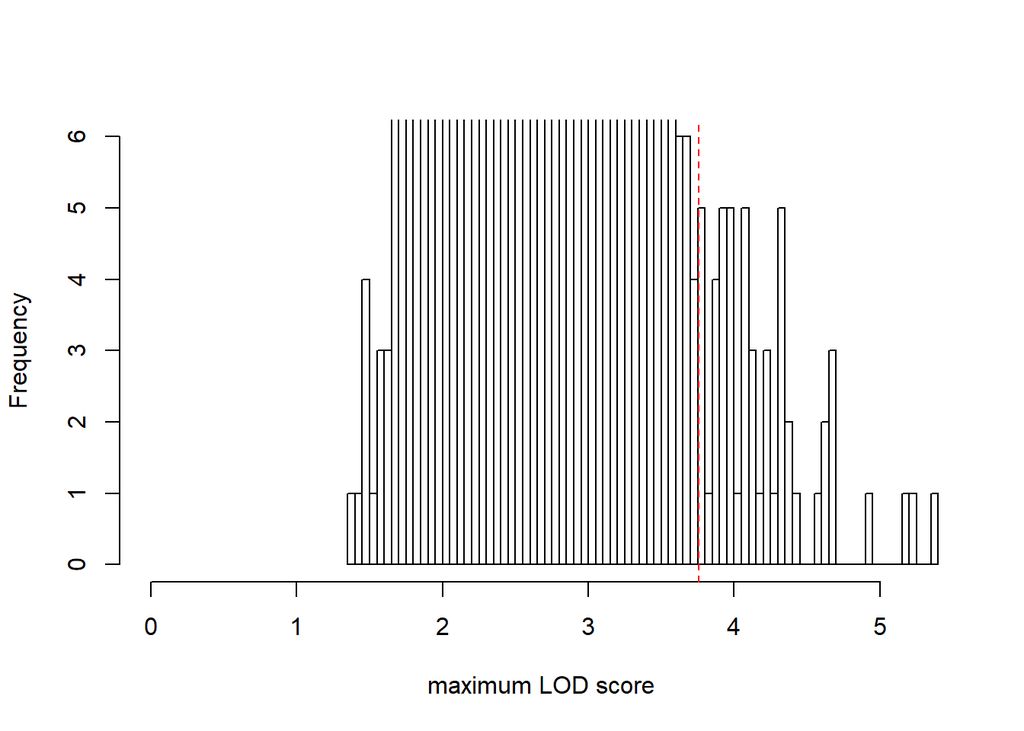

```r
{plot(mimulus_qtl_perm, ylim = c(0,6))
      abline(v=threshold_im, lty= 2, col= "red")}
```

## Mapeamento por Intervalo (IM)

1)Escaneando o genoma -para identificar cromossomos com efeito

```r
mimulus_qtl.em= scanone(pheno.col = 4, mimulus.qtl.probs, method = "em")
sum_qtl_em = summary(mimulus_qtl.em, perm= mimulus_qtl_perm, alpha = 0.05, pvalues = TRUE)
sum_qtl_em
```

```
##           chr pos  lod  pval
## c12.loc13  12  13 4.11 0.026
```

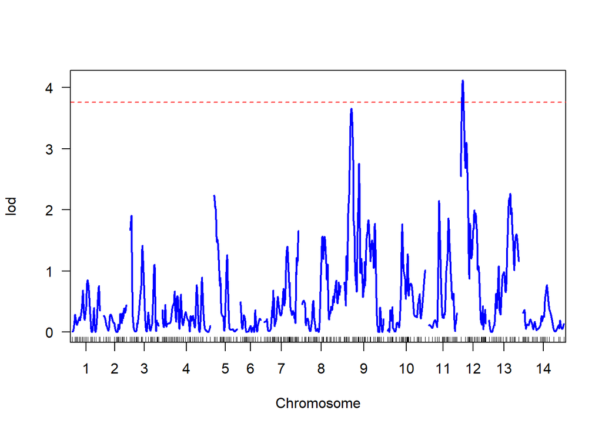

```r
{plot(mimulus_qtl.em, col = "blue")
      abline(h=threshold_im, lty = 2, col="red")}
```

- O cromossomo 12 foi único que teve efeito significativo de QTL para a caracteristica analisada.

Cromossomo 12:

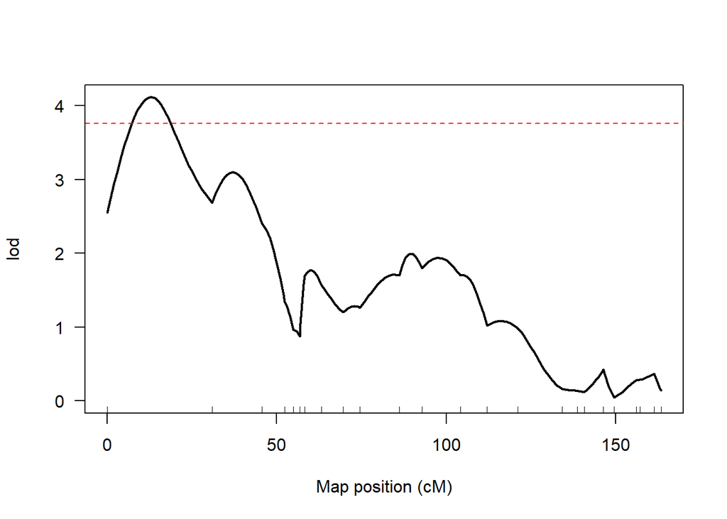

```r
chr_12= scanone(mimulus.qtl.probs, method = "em", pheno.col = 4,tol = 1e-6, chr= 12)
{plot(chr_12)
      abline(h =threshold_im, lty=2 , col= "red") }
```

QTL:

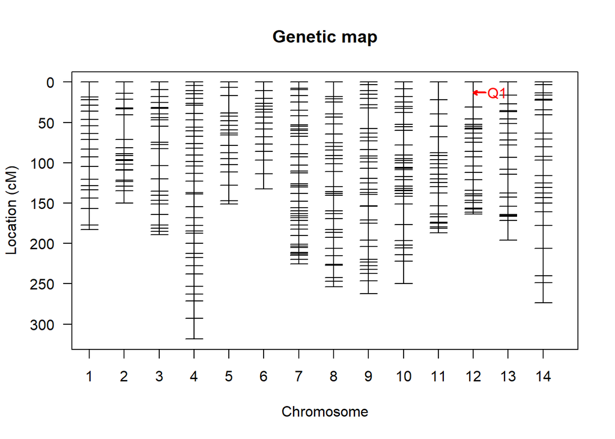

```r
qtl_im= makeqtl(mimulus.qtl.probs, chr = sum_qtl_em$chr, pos = sum_qtl_em$pos, what = "prob")
plot(qtl_im)
```

Analisando o cromossomo 12:

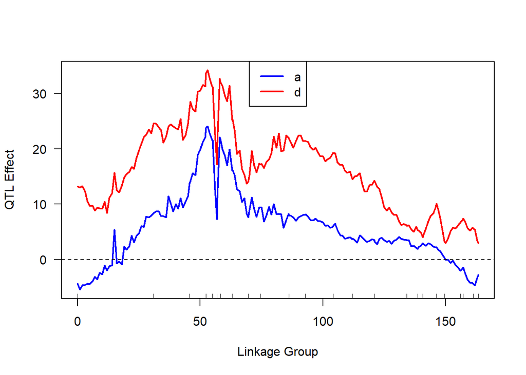

```r
mimulus_12= sim.geno(mimulus.qtl.probs, n.draws = 16, step = 1, off.end = 0,
                     error.prob = 0.0001, map.function = "kosambi")

chr_12_effect= effectscan(mimulus_12, pheno.col=4, chr = 12, get.se=FALSE, draw =TRUE, gap = 25,                                          mtick=c("line","triangle"),add.legend=TRUE, alternate.chrid=FALSE,
                          ylab="QTL Effect", xlab="Linkage Group")
```

```r
#abline(v = sum_qtl_em$pos, lty= 2, col="orange")}
```

Efeito dos QTLs:

```r
qtl= fitqtl(mimulus.qtl.probs, pheno.col = 4, qtl = qtl_im, method = "hk", get.ests = TRUE)
efeitos = summary(qtl)
```

```r
additive= efeitos$ests[2,1]
dominance= efeitos$ests[3,1]
(table_im= data.frame("Linkage Group"= sum_qtl_em$chr[1],
                     "Position"= sum_qtl_em$pos[1],
                     "LOD"=sum_qtl_em$lod[1],
                     "Additive effect"= efeitos$ests[2,1],
                     "Dominance effect"= efeitos$ests[3,1]))
```

```
##   Linkage.Group Position      LOD Additive.effect Dominance.effect
## 1            12       13 4.114837        12.83873         53.95948
```

## Mapeamento por Intervalo Composto (CIM)

```r
mimulus_cim= read.cross(format = "mm",file = "m_feb06.raw", mapfile="test_sum.txt")
```

```
##  --Read the following data:
##  Type of cross:          f2
##  Number of individuals:  287
##  Number of markers:      418
##  Number of phenotypes:   16
##  --Cross type: f2
```

1)Ajustando marcadores sobrepostos

```r
mimulus_cim_jm= jittermap(mimulus_cim)
summary(mimulus_cim_jm)
```

```
##     F2 intercross
##
##     No. individuals:    287
##
##     No. phenotypes:     16
##     Percent phenotyped: 96.2 93.4 96.2 93 95.8 87.8 96.2 95.8 96.2 96.2
##                         90.2 96.2 95.8 96.2 95.8 96.2
##
##     No. chromosomes:    14
##         Autosomes:      1 2 3 4 5 6 7 8 9 10 11 12 13 14
##
##     Total markers:      379
##     No. markers:        19 20 24 36 19 18 43 32 35 37 24 26 21 25
##     Percent genotyped:  89.4
##     Genotypes (%):      AA:16.3  AB:25.3  BB:23.1  not BB:19.9  not AA:15.5
```

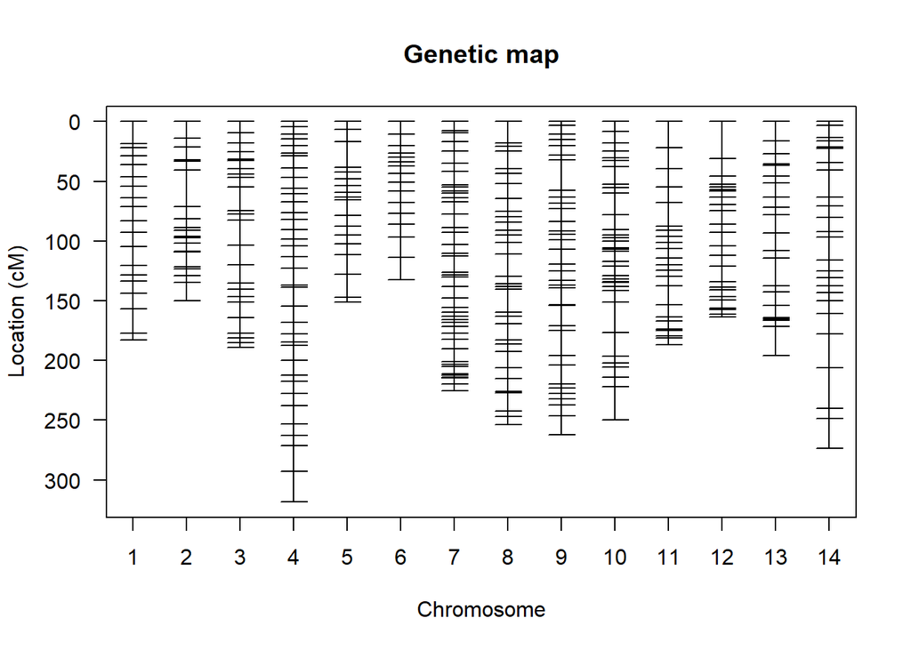

```r
plot.map(mimulus_cim_jm)
```

2)Calculo das probabilidades condicionais

```r
mimulus_cim_prob = calc.genoprob(mimulus_cim_jm, step = 1, error.prob = 0.0001)
```

3)Identicando as covariaveis

```r
stepwiseqtl(mimulus_cim_prob, pheno.col = 4, method = "hk", covar = NULL, model = "normal",
            incl.markers = TRUE, refine.locations = TRUE, additive.only = FALSE, scan.pairs = FALSE,
            keeplodprofile=TRUE, keeptrace=FALSE, verbose=TRUE, require.fullrank=FALSE)
```

[output not shown]

[output cut: 182 more lines]

```
##     no.qtl =  4   pLOD = -0.6952912   formula: y ~ Q1 + Q2 + Q3 + Q4
##  ---Refining positions
##  ---  Moved a bit
##  ---Dropping Q2
##     no.qtl =  3   pLOD = -1.66458   formula: y ~ Q1 + Q2 + Q3
##  ---Refining positions
##  ---  Moved a bit
##  ---Dropping Q1
##     no.qtl =  2   pLOD = -1.991379   formula: y ~ Q1 + Q2
##  ---Refining positions
##  ---Dropping Q2
##     no.qtl =  1   pLOD = -3.445336   formula: y ~ Q1
##  ---Refining positions
##  ---  Moved a bit
##  ---One last pass through refineqtl
```

```
##   QTL object containing genotype probabilities.
##
##       name chr pos n.gen
## Q1  9@49.0   9  49     3
## Q2 12@13.0  12  13     3
##
##   Formula: y ~ Q1 + Q2
##
##   pLOD:  1.007
```

4)Determinacao do threshold:

```r
mimulus_cim_perm= cim(mimulus_cim_prob, method = "hk", n.marcovar = 3, pheno.col = 4, n.perm = 1000)
```

```r
summary(mimulus_cim_perm, alpha= c(0.05, 0.01))
```

```
## LOD thresholds (1000 permutations)
##    [,1]
## 5% 4.33
## 1% 5.27
```

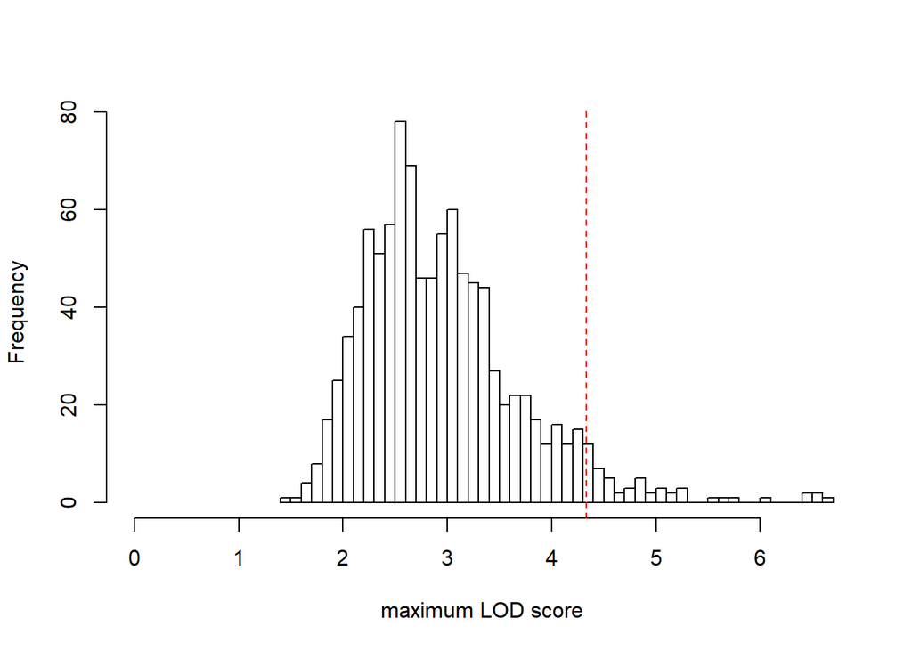

```r
threshold_hk_cim <- summary(mimulus_cim_perm, alpha = 0.05)
{plot(mimulus_cim_perm)
      abline(v=threshold_hk_cim, lty = 2, col = "red")}
```

5)Mapeamento

-uso da funcao de mapeamento de Kosambi

```r
mimulus_qtl_cim= cim(mimulus_cim_prob, method = "hk", pheno.col = 4, n.marcovar = 3, map.function = "kosambi")
```

5)Identificando os QTLs significativos

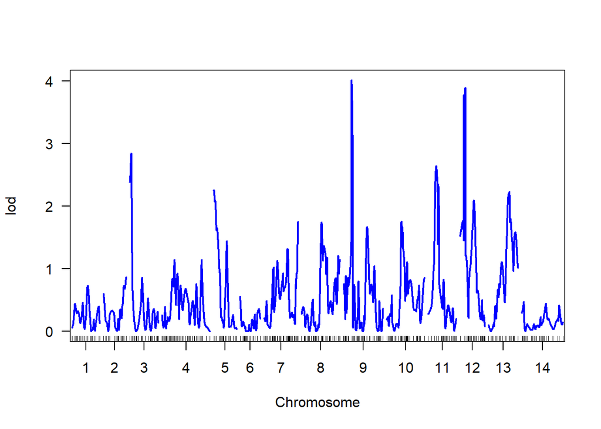

```r
sum_qtl_cim= summary(mimulus_qtl_cim, perms = mimulus_cim_perm, alpha = 0.05, pvalues = TRUE)
{plot(mimulus_qtl_cim,col= "blue")
      abline(h = threshold_hk_cim,lty=2, col= "orange")}
```

## Final considerations:

In this exercise, the Mimulus dataset was analyzed. From the construction of the genetic map, performed in previous analyzes, using Onemap, we were able to obtain information about the positioning of the markers in the linking groups. From data, we proceeded with the identification of QTLs using two methods: 1) Interval mapping (IM): is based on limiting the region of analysis of the possible QTL, from two flanking markers. In this analysis, only one QTL is considered at a time, so if there are other QTLs that influence the evaluated phenotype, this effect will inflate the residue, which will reduce the power of the test. 2) Compound interval mapping (CIM): this is consolidated in an extension of the interval mapping, however, other QTLs that have an effect on the trait are added to the model, as covariates, in order to increase the detection power of the QTL. It was used the R environment for the analysis, using the R / qtl software, and all the procedures were done only for one trait. By Interval Mapping, when using permutations to define the threshold of significance, with 1000 permutations, the lod was determined in 3.76 to 5%. Then, it was possible to identify evidence of the presence of 1 QTL on chromosome 12 in position 13. In estimating the effects of this QTL, the values of 12.83 for additive effect and 53.95 for dominance were identified. By composite interval mapping it is possible to fit the model that best represents the data. It is possible to identify which marks are important for the phenotype under study, thus, these marks are added to the model as covariates. This is a very important step because it is responsible for reducing the residue, which favors the increase of the QTL detection power. By this approach, it was not possible to identify peaks that could represent a putative QTL. It was concluded that the Interval Mapping was able to identify a certain QTL, whereas by the CIM, no QTL was identified. This fact may be related to the indication of false positives by IM, because as its residue is inflated, the detection power is lower, and however, it was still able to identify QTL, probably erroneously.